# Estimating Rate of Change in Genome Size Evolution Across Insect Taxa

Joshua R. Nilsson

2026-04-21

# Overview

- **Part 1:** Loading genome size data and taxonomy, normalizing taxon names, resolving duplicate genome size records, and cross-referencing species between datasets
- **Part 2:** Pruning the phylogenetic trees to retain only taxa with matched genome size data
- **Part 3:** Converting the ML tree to ultrametric form and estimating BAMM priors

# Part 1: Tip Search and Genome Size Matching

## Libraries

```r
library(tidyverse)
library(readxl)
library(janitor)
```

## Data Sources

Two datasets were used:

- **insectgs.csv**: Genome size (GS) data sourced from an online genome size database, containing C-value measurements in picograms (pg) and megabase pairs (Mbp), measurement method, and metamorphosis type
- **List_of_4854_insects&10_outgroups.xlsx**: Supplementary taxonomy file accompanying the phylogenetic tree, containing 4,864 taxa (4,854 insects + 10 outgroups) with full taxonomic rank information and tip labels matching the tree file

## Load Files

```r
gs_df  <- read_csv("insectgs.csv", locale = locale(encoding = "latin1"))
tip_df <- read_xlsx("List_of_4854_insects&10_outgroups.xlsx") |> clean_names()
```

The `latin1` encoding was required for the GS CSV due to special characters present in some species names. `clean_names()` from the `janitor` package was applied to standardize column names in the taxonomy file.

## Genome Size Duplicate Resolution

The GS dataset contained 773 duplicate species entries with differing genome size values, reflecting multiple measurements in the database. Duplicates were resolved by preferring the most reliable measurement method for each species, then averaging if multiple records of the same best method existed.

The `Method` column indicates the technique used to measure genome size:

| Method | Description | Rank |
| --- | --- | --- |
| FCM | Flow Cytometry — gold standard | 1 |
| FIA | Feulgen Image Analysis | 2 |
| FD | Feulgen Densitometry | 3 |
| BCA | Biochemical Analysis | 4 |
| NS / Other | Not Specified or other | 5 |

A coefficient of variation (CV) was retained to flag species where records disagreed substantially, providing a transparency trail for downstream analyses.

**Note on C-value vs Mbp:** Both columns represent the same measurement in different units (1 pg ≈ 978 Mbp). The conversion factor was confirmed consistent across the dataset. Mbp was retained for all downstream analyses.

```r
gs_resolved <- gs_df |>
  mutate(method_rank = case_when(
    Method == "FCM" ~ 1,
    Method == "FIA" ~ 2,
    Method == "FD"  ~ 3,
    Method == "BCA" ~ 4,
    TRUE            ~ 5
  )) |>
  group_by(Name) |>
  slice_min(method_rank, with_ties = TRUE) |>
  summarise(
    gs_value      = mean(Mbp, na.rm = TRUE),
    gs_sd         = sd(Mbp, na.rm = TRUE),
    gs_cv         = gs_sd / gs_value,
    best_method   = first(Method),
    metamorphosis = first(Metamorphosis),
    n_records     = n(),
    .groups       = "drop"
  ) |>
  mutate(
    name_normalized = Name |>
      str_to_lower() |>
      str_replace_all("-", "") |>    # strip hyphens to match tip formatting
      str_squish()
  )
```

## Name Normalization

Taxon names required normalization prior to matching due to formatting differences between the two files:

- The taxonomy file encodes tip labels as `Order_Genus_species` (e.g. `Coleoptera_Anthonomus_grandis`)
- Some tip labels contain additional identifiers for subspecies or unidentified specimens (e.g. `Coleoptera_Anthonomus_grandis_grandis`)
- The GS file uses standard binomial nomenclature with spaces (e.g. `Anthonomus grandis`)
- Some GS names contain hyphens absent in the tip labels (e.g. `Xestia c-nigrum` vs `Xestia_cnigrum`)

To address these issues:

- Tip labels were normalized by extracting the **2nd and 3rd underscore-delimited words** (genus + species epithet), ensuring subspecies suffixes are ignored
- GS names were converted to lowercase and hyphens were stripped to match tip label formatting
- Original names were preserved in all cases; normalization was applied to new columns only

```r
tip_df <- tip_df |>
  mutate(
    name_normalized = tip_names_in_data_matrix |>
      str_split("_") |>
      map_chr(~ paste(.x[2], .x[3], sep = " ")) |>
      str_to_lower() |>
      str_squish()
  )
```

## Cross-Referencing

```r
gs_to_join <- gs_resolved |>
  select(name_normalized, gs_value, gs_sd, gs_cv,
         best_method, metamorphosis, n_records)

matches <- tip_df |>
  inner_join(gs_to_join, by = "name_normalized") |>
  select(
    tip_names_in_data_matrix,
    kingdom, phylum, subphylum, class, subclass, infraclass,
    cohort, order, suborder, infraorder,
    superfamily, family, subfamily, genus, species,
    metamorphosis, gs_value, gs_sd, gs_cv, best_method, n_records
  )

unmatched_tips <- anti_join(tip_df, gs_resolved, by = "name_normalized")
unmatched_gs   <- anti_join(gs_resolved, tip_df, by = "name_normalized")
```

## Matching Results

```r
cat("Tree tips with GS data:   ", nrow(matches), "\n")
cat("Tree tips WITHOUT GS data:", nrow(unmatched_tips), "\n")
cat("GS species not in tree:   ", nrow(unmatched_gs), "\n")
```

```
## Tree tips with GS data:    405
## Tree tips WITHOUT GS data: 4459
## GS species not in tree:    1201
```

405 of 4,864 tree tips (~8%) were successfully matched to genome size data. The low match rate reflects the sparsity of published genome size data relative to the scale of the phylogeny. The 4,459 unmatched tips include species for which no genome size data exists, and unidentified specimens (e.g. `Scymnus sp. 1 HSL-2020`) which are structurally unmatchable at species level. These unidentified specimens retain genus-level labels and will be captured in planned genus- and family-level analyses.

High-variance matches (CV > 10%) were flagged for review:

```r
high_variance <- matches |>
  filter(!is.na(gs_cv), gs_cv > 0.1) |>
  select(tip_names_in_data_matrix, species, gs_value, gs_sd,
         gs_cv, best_method, n_records) |>
  arrange(desc(gs_cv))
```

## Output

```r
write.csv(matches, file = "Matched_Tips.csv")
```

# Part 2: Tree Pruning

## Libraries

```r
library(ape)
library(tidyverse)
```

## Load Files

```r
matches     <- read_csv("Matched_Tips.csv")
astral_tree <- read.tree("Tree_dat/10outgroups_4854insects_824genes_ASTRAL_rooted_final.tree")
ml_tree     <- read.tree("Tree_Dat/10outgroups_4854insects_824genes_MLbest_rooted.tree")
```

Two trees were provided with the dataset:

- **ASTRAL tree**: Coalescent-based species tree estimated with ASTRAL from 824 genes. Branch lengths are in coalescent units and tip branch lengths are absent (expected ASTRAL behavior)
- **ML tree**: Maximum likelihood concatenated tree with branch lengths in substitutions per site

## Pruning

```r
tips_to_keep <- matches$tip_names_in_data_matrix

prune_tree <- function(tree, keep_tips) {
  tips_to_drop <- tree$tip.label[!tree$tip.label %in% keep_tips]

  if (length(tips_to_drop) == 0) {
    message("No tips to drop.")
    return(tree)
  }

  pruned <- drop.tip(tree, tips_to_drop, trim.internal = TRUE)
  message(paste("Dropped:", length(tips_to_drop), "tips"))
  message(paste("Remaining:", length(pruned$tip.label), "tips"))
  return(pruned)
}

astral_pruned <- prune_tree(astral_tree, tips_to_keep)
ml_pruned     <- prune_tree(ml_tree, tips_to_keep)
```

## Verify and Save

```r
is.rooted(astral_pruned)
is.rooted(ml_pruned)

write.tree(astral_pruned, "ASTRAL_pruned.tree")
write.tree(ml_pruned,     "ML_pruned.tree")
```

```
## [1] TRUE
## [1] TRUE
```

# Part 3: Ultrametric Conversion and BAMM Priors

## Libraries

```r
library(tidyverse)
library(ape)
library(BAMMtools)
```

## Load Files

```r
matches <- read_csv("Matched_Tips.csv")
ml_tree <- read.tree("ML_pruned.tree")
```

The ML tree was used for BAMM prior estimation. The ASTRAL tree was not used for this step because ASTRAL branch lengths are in coalescent units rather than substitutions per site, which are required by `chronos()` and BAMM. For the final analysis, MCMCtree will be used for divergence time estimation with multiple fossil calibration points.

## Ultrametric Conversion

The ML tree was converted to ultrametric form using penalized likelihood rate smoothing via `chronos()` in the `ape` package. The optimal smoothing parameter (lambda) was selected by minimizing cross-validation error across a range of values (`10^-1` to `10^6`):

```r
l     <- 10^(-1:6)
cv_ml <- numeric(length(l))
for(i in 1:length(l)){
  print(i)
  cv_ml[i] <- sum(attr(chronopl(ml_tree, lambda = l[i], CV = TRUE), "D2"))
}
plot(l, cv_ml)
```

A single root calibration point was used for this preliminary analysis:

- **Root calibration:** *Orchesella cincta* (Collembola) vs *Drosophila elegans* (Diptera) = **459 MYA**

```r
cal_ml  <- makeChronosCalib(ml_tree, node = "root", age.min = 459, age.max = 459)
ML.tree <- chronos(ml_tree, lambda = l[which.min(cv_ml)],
                   model = "correlated", calibration = cal_ml)
is.ultrametric(ML.tree)
write.tree(ML.tree, file = "MLTree.tree")
```

```
## [1] TRUE
```

**Note:** This is a preliminary single-calibration analysis. Final analyses will incorporate multiple fossil calibration points across insect orders to improve divergence time accuracy at deep nodes.

## BAMM Prior Estimation

Genome size values were formatted as a named numeric vector with tip labels as names, then passed to `setBAMMpriors()`. A sanity check confirmed all names matched the tree tips exactly before running:

```r
gs_vector <- setNames(matches$gs_value, matches$tip_names_in_data_matrix)

all(names(gs_vector) %in% ML.tree$tip.label)

setBAMMpriors(phy = ML.tree, traits = gs_vector, outfile = "ml_priors.txt")
```

```
## [1] TRUE
```

The output file `ml_priors.txt` contains the `betaInitPrior` and `betaShiftPrior` values to be copied into the BAMM configuration file.

# Part 4: Genome Size Visualization

## Continuous Trait Mapping

Genome size evolution was visualized on the time-calibrated ML tree using continuous trait mapping via `contMap()` from the `phytools` package [@revell2012phytools]. Ancestral genome sizes were reconstructed under Brownian motion, with branch colors representing genome size from small (blue) to large (red).

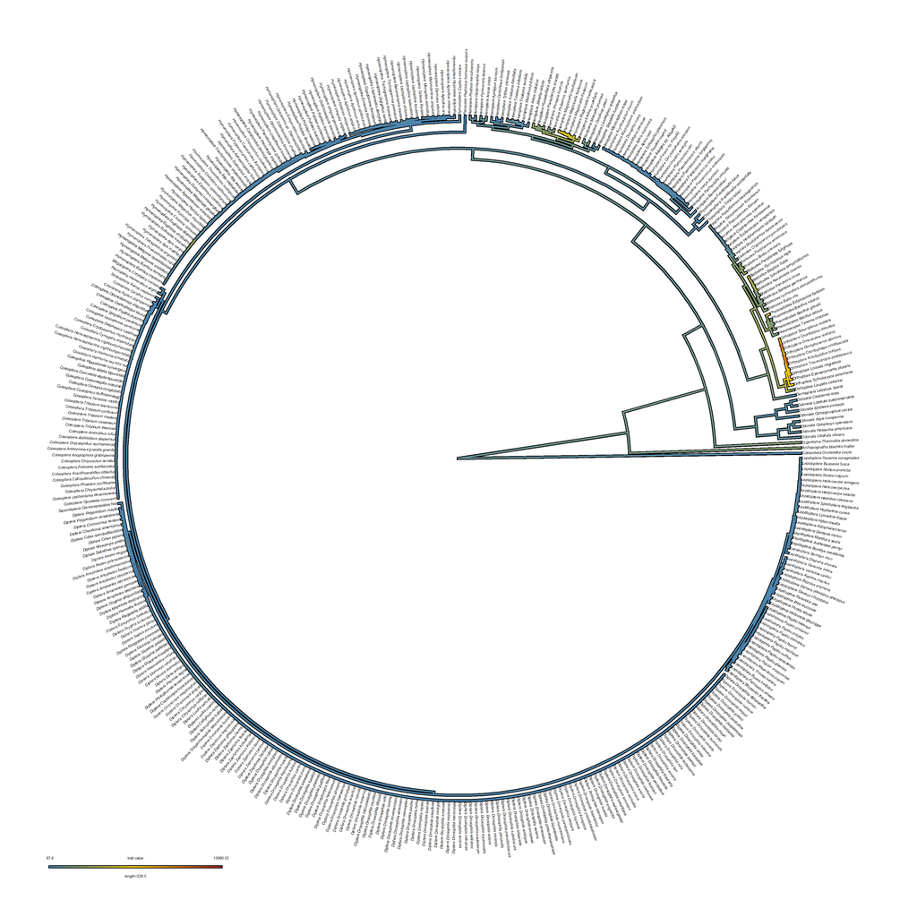

Continuous trait map of genome size (Mbp) across insect phylogeny. Branch colors represent reconstructed genome size from small (blue) to large (red).

```r
library(phytools)

gs_vector  <- setNames(matches$gs_value, matches$tip_names_in_data_matrix)
gs_vector  <- gs_vector[ML.tree$tip.label]

gs_contmap <- contMap(ML.tree, gs_vector, plot = FALSE)
gs_contmap <- setMap(gs_contmap, colors = c("steelblue", "gold", "firebrick"))

plot(gs_contmap,
     type   = "fan",
     legend = 0.5 * max(nodeHeights(ML.tree)),
     lwd    = 2,
     fsize  = 0.3,
     ftype  = "i")
```